# Introduction to R aka Stats comes alive!

# goals

- Learn what R is and what it’s used for
- Import data into R
- Learn basic data manipulation
- Run some basic statistical tests:
- correlation test
- t test

# what is R?

R is a statistical programming langauge. You can use R to do basic programming tasks but the real strength of R is in formulating statistical models, running statistical tests, and creating visualizations.

Examples of things you might do with R:  
- run statistical tests  
- calculate the average of a set of numbers  
- produce a bar plot  
- parse data from Twitter

Like all successful programming languages, R allows users to contribute code that extends the basic functionally of R. Whenever you can, use these ‘packages’: it will save you time and be more robust than if you were to code everything yourself.

# some basics

Everything that `looks like this` is code that is meant to be entered at the command prompt or console.

To try to understand what a function does, type a `?` before the function name. One of R’s most elementary functionas, `c`, is used to concatetate things together. Type `?c` to see the help file and examples for how to use this function.

# import data into R

We’ll learn some basics of R by doing some simple analyses of part of a previous published dataset. The paper can by found here: http://journals.plos.org/plosone/article?id=10.1371/journal.pone.0156589#sec014. The paper tests whether male and female guppies have similar affinities for a novel object.

You tell R to do things by typing things at what’s called the command line. At it’s most fundamental, there is no point-and-click interface in R.

We’ll start by loading a **package**. A package is a collection of functions that someone else wrote. *Functions* execute some series of commands in R. Packages extend the functionality of R and allow you to do a lot more than you could do by yourself. You know something is a function because there will always by parentheses around the function, like `c()`.

You can install packages with the `install.packages` function. For example, typing `install.packages("tidyverse")` will install the *tidyverse* package (the quotations around *tidyverse* are important!). Packages have to be installed first before they can be loaded for use.

You can load packages with the `library` function. Functions like `library` usually have one or more *arguments*, also called *parameters*. Let’s see this in action with the `library` function:

```r
library("tidyverse")
```

In the command above, `library` is the function name and *“tidyverse”* is the argument. This command tells R to make all the functions in the `tidyverse` package accessible to me.

Now let’s try to import the data.

## read_csv

There are lots of functions we can use to import data into R. Usually we import some kind of spreadsheet into R, usually from a program like Excel. It is usually easiest to save Excel files that are *comma separated* or `csv` files rather than the normal Excel format. In Excel, when you click File -> Save As…, there is an option to save your file as .csv files instead of the normal excel file. csv files are play nice with R because they are just text.

We can use the `read_csv` function to read in csv files. The main argument is the path to the csv file–the location or address of the csv file on your hard drive.

Finally, we use the `<-` operator to assign the output of the function to an *object*. An object is just the name for something. That something could be a number or a dataframe or a column of a datafrmame.

We can name the object anything we want. I’m going to assign the output of the `read_csv` function to an object called `df`. If you don’t know where this file is located on your computer, run `df <- read_csv(file.choose())` instead to look for it yourself.

```r
df <- read_csv("/Users/lukereding/Desktop/r_presentation/data/for_presentation.csv")
```

To see what the `df` object is, we can just type `df` and press Enter:

```r
df
```

```
## # A tibble: 31 × 6
##       `fish`   sex familiarization interval time_in_central_corridor
##        <chr> <chr>           <chr>    <chr>                    <dbl>
## 1  female 01     F              3h      6gg                0.1666667
## 2    male 01     M              3h      6gg                0.2666667
## 3  female 02     F              3h      6gg                0.2666667
## 4    male 02     M              3h      6gg                0.2333333
## 5  female 03     F              3h      6gg                0.3000000
## 6    male 03     M              3h      6gg                0.2000000
## 7  female 04     F              3h      6gg                0.2000000
## 8    male 04     M              3h      6gg                0.2000000
## 9  female 05     F              1h      6gg                0.4333333
## 10   male 05     M              1h      6gg                0.2833333
## # ... with 21 more rows, and 1 more variables:
## #   preference_for_novel_object <dbl>
```

`df` is a *dataframe*. This is a columnal data structure in R and the main type of structure you’ll work with. A dataframe is just like an Excel spreadsheet: there are rows and columns. Unlike an Excel spreadsheet, everything has to be tidy and neat in an R dataframe. A dataframe is just entries in the rows and columns: there are no other cells, no plots, no summary statistics associated with the dataframe like there might be in an Excel spreadsheet.

## data types in R

Each variable in the dataframe has a *data type* associated with it. *Types* are how you tell R what sort of data each variable is. Here are some popular data types:

- **numeric**: numbers. Numbers can be integers (1, 2, 3, …) or doubles (floating point decimals like 0.654334 or 1/3). examples: 2, 7.521, 1e-7, 0.2
- **factors**: groups or categories. examples: treatment and control. low-dose, high-dose, control.
- **logical**: yes/no or true/false.
- **characters**: words. examples: “banana”, “a”, “Luke”, “resting”

When you type in `df`, R tells you what type each variable is under the name of the column. For example, under `fish` is `(chr)`. `chr` stands for *character*. Same thing for `sex`.

The problem is that sex is a factor: sex represents two groups or categories of fish. Below I convert the `sex` column from a character to a factor:

```r
df$sex <- factor(df$sex)
```

We use the `$` to specify a column of a dataframe. So typing `df$sex` just gives us the `sex` column of `df`. You can try typing `df$sex` in the Console to see the output. So this line of code tells R, ‘Make the sex column of the `df` dataframe a factor. Replace the old sex column with the new, factored, sex column.’

I used the `factor` function to tell R that the `sex` column is a factor. Now type in `df`. Under `sex` R reports `(fctr)`, letting us know that the `sex` column is now a factor.

Note that nothing happened when we ran that. R will give you an error or warning message if something went wrong, otherwise, it will simply do what you tell it. In this case, we only told R to assign the column `sex` in the dataframe `df` as a factor.

# questions

For our purposes today, let’s ask two questions of this dataset:

1. Do the sexes differ in their preference for a novel object?
2. Is there a relationship between the preference for a novel object and the time the fish spends in the central corridor?

Any good data analysis has at least two parts:

1. visualizing the data
2. performing some statistical test

We’ll go through these steps for both these questions.

# Do the sexes differ in their preference for a novel object?

## visualizing

We want to visualize the relationship between a categorcial variable–sex–and a continuous, numeric variable–preference for the novel object. One common way of representing the relationship between a continuous and categorical variable is with a boxplot.

We’ll use a package called `ggplot2` to make our boxplot. We already loaded `ggplot2` when we loaded `tidyverse`.

`ggplot` takes a bit of getting used to but it’s very powerful and the main way of plotting things in R.

To create a plot using `ggplot` requires first using the `ggplot` function. The first argument is the dataframe with the data we want to plot. The second argument is actually another function! A little mind-bending, but stick with it. In this function, called `aes`, we place all the things we want to plot. Here, we just want to plot the relationship between `sex` and `preference_for_novel_object`, so that’s what we enter into the `aes` function.

The `ggplot` function is followed by additional functions that add things layer-by-layer to the plot. Just running the `ggplot` function alone doesn’t do much:

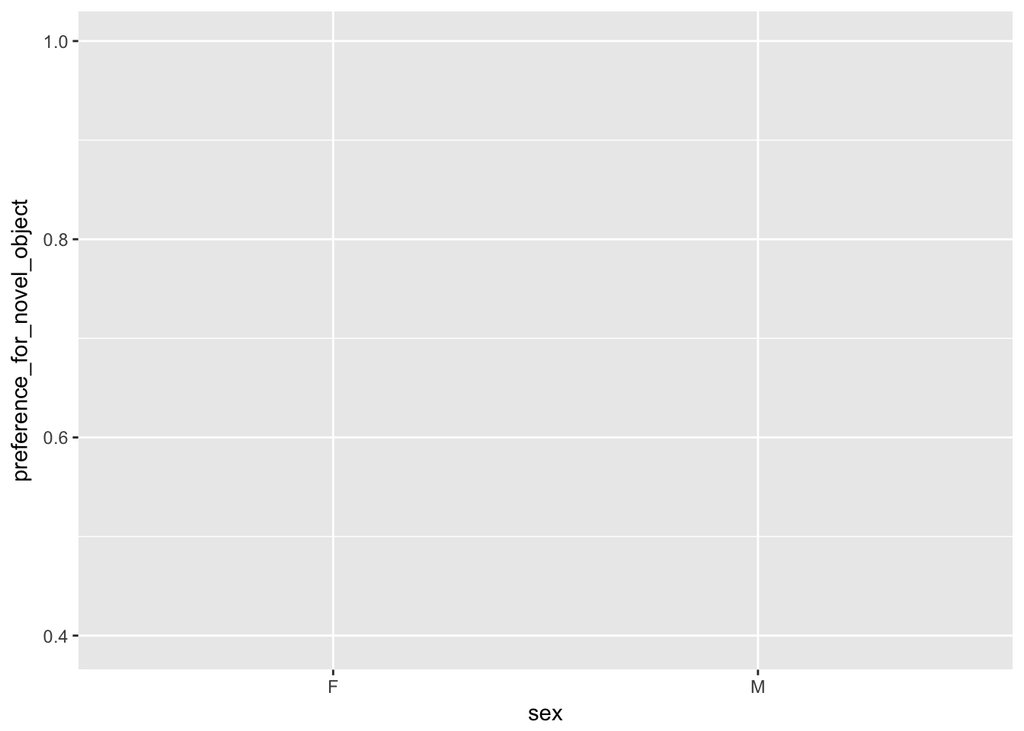

```r
ggplot(data = df, mapping = aes(x = sex, y = preference_for_novel_object)) # set up the ggplot
```

The variables are on the right axes, but there’s nothing there! We have to tell ggplot exactly what we want. `ggplot` comes with several *geoms* or geometries that you can add to the plot. Example *geoms* include bars (for bar plots), boxes (for boxplots), points (for scatterplots), and lines. A list of all available ggplot geoms can be found on the ggplot [website](http://docs.ggplot2.org/current/).

So now I re-do the ggplot adding a `+` sign followed by the geom I want to use:

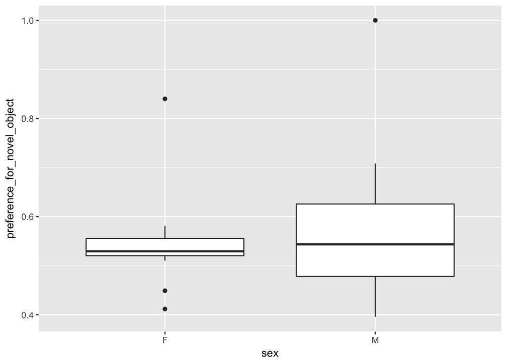

```r
ggplot(data = df, mapping = aes(x = sex, y = preference_for_novel_object)) + # set up the ggplot
  geom_boxplot()
```

Now we have the boxplot we wanted.

The nice thing about `ggplot` is that the plot is built in layers, so it’s easy to add, for example, the data points that make up each box by adding the geom for points:

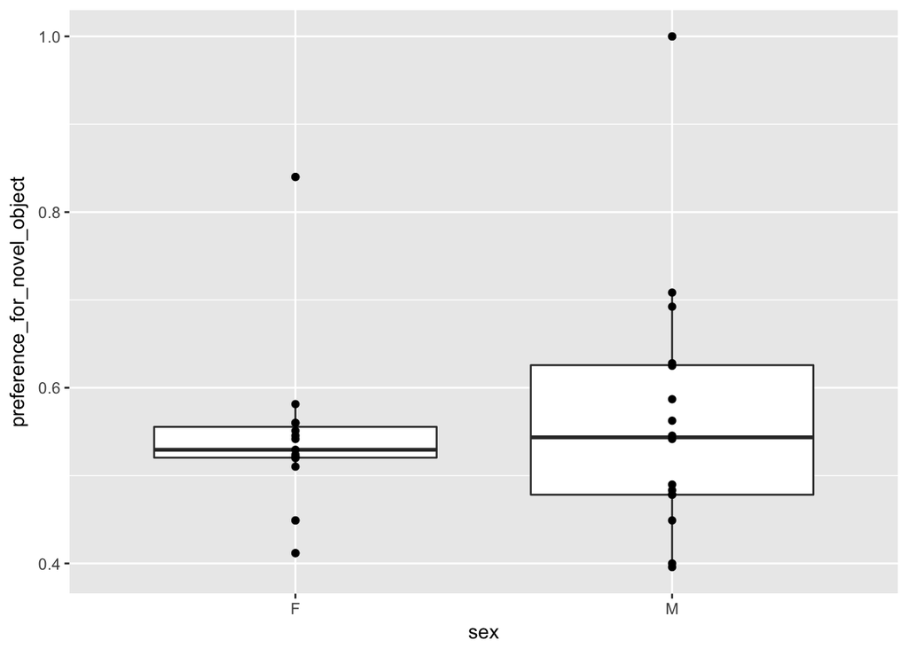

```r
ggplot(data = df, mapping = aes(sex, preference_for_novel_object)) + # set up the ggplot
  geom_boxplot() + # add the boxplots
  geom_point() # add the points
```

From the plot, we see a couple things:

1. The median preference for the novel object is similar in males and females.
2. The preferences of the male guppies are more variable.

## stats

We can eyeball the boxplot above and see that there likely isn’t a relationship between `sex` and `preference` since the boxplot medians are at similar heights. This really isn’t good enough though. **We can use a statistical test to tell us the probability of getting these results if there is no difference in the average preference between male and female guppies.**

To test whether the averages of two groups are the same, we can use a **t-test**. It’s beyond the scope of this lecture, but there are some assumptions that a t-test makes; you should pay attention to these assumptions whenever you use a t-test in your own work.

R’s `t.test` function can be used to perform a t.test.

The function’s argument is a little tricky. It takes the form of `y ~ x`. The `~` can be read as *as a function of*. So `y ~ x` just means *y as a function of x*. Swap out the y and x with the names of your variables. The variable on the x-axis in the plot above is sex and the variable on the y-axis is preference. Finally, tell R what dataframe you’re using with the `data =` argument (remember that if you every get an error when attempting to use a function, like `t.test`, to see the help file with `?t.test`):

```r
t.test(preference_for_novel_object ~ sex, data = df)
```

```
##
##  Welch Two Sample t-test
##
## data:  preference_for_novel_object by sex
## t = -0.50082, df = 25.3, p-value = 0.6208
## alternative hypothesis: true difference in means is not equal to 0
## 95 percent confidence interval:
##  -0.11302198  0.06878549
## sample estimates:
## mean in group F mean in group M
##       0.5444186       0.5665369
```

There’s a lot of information in the output of the test. For out purposes, the main thing to look for the is **p value**: this is the probability of getting the results we got or more extreme results if there is no difference in the average preference for a novel object between males and females. A p-value is a probability, so it ranges between 0 and 1. A low p-value (usually < 0.05) means that the result is very improbable if there are no differences between groups. A higher p-value, like the one we got above (0.62), suggests that are data are not unlikely if there is no relationship between sex and preference.

# Is there a relationship between the preference for a novel object and the time the fish spends in the central corridor?

## visualizing

Before, we were interested in visualizing the relationship between a *continuous variable*–a variable that can take any value within some range of values–and a *categorical variable*, otherwise known as a *factor*. Now, we’re interested in whether there’s a relationship between two continuous variables–a fish’s preference for a novel object and the proportion of time the fish spends in the central corridor.

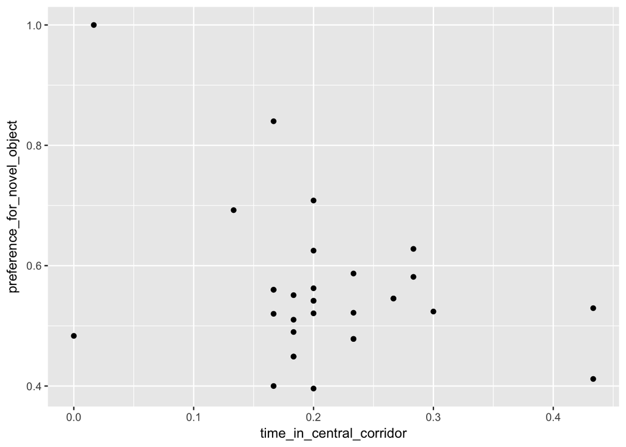

```r
ggplot(data = df, mapping = aes(x = time_in_central_corridor, y = preference_for_novel_object)) + # set up the ggplot
  geom_point() # add points
```

It’s often helpful when plotting a scatterplot to add a trend line. This line provides an easy way for someone to see how preference for the novel object changes as time in the central corridor increases.

We can use a new ggplot geom–`geom_smooth`–to add this trend line to the plot:

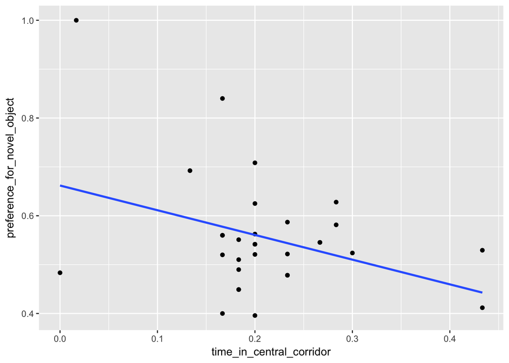

```r
ggplot(data = df, mapping = aes(time_in_central_corridor, preference_for_novel_object)) + # set up the ggplot
  geom_point() + # add points
  geom_smooth(se = FALSE, method = "lm") # add line
```

(Note that the `geom_smooth` function has some additional arguments. That’s just to make the output a little simpler; if you’d like to understand what the arguments mean, check the help file but typing `?geom_smooth` into the Console.)

Now it’s easy to see that, in general, as time spent in the corridor increases, preference for the novel object declines. But how likely is this trend to exist by chance alone?

## stats

We can use statistics to tell us whether is likely to get a negative trend like we see above simply by chance alone if there is no association between time spent in the corridor and preference.

We can use a *correlation test* to determine whether it’s unlikely to see a negative trend this strong by chance. The `cor.test` function in R implements this test.

Unlike a lot of the functions above, `cor.test` doesn’t accept a `data =` argument. Instead, we have to give it the columns individually from the dataframe using the `$` notation we learned about above:

```r
cor.test(df$time_in_central_corridor, df$preference_for_novel_object)
```

```
##
##  Pearson's product-moment correlation
##
## data:  df$time_in_central_corridor and df$preference_for_novel_object
## t = -2.0657, df = 29, p-value = 0.04789
## alternative hypothesis: true correlation is not equal to 0
## 95 percent confidence interval:
##  -0.632254731 -0.004366775
## sample estimates:
##        cor
## -0.3581527
```

The p-value here is less than 0.05, the traditional cutoff. Thus we conclude that it is unlikely we would see a correlation this strong if there was no relationship between time spent in the central corridor and preference.

# exercises (for fun!)

## basic

1. Find the help file for the `geom_boxplot` function. What does the notch argument do? Try adding notches to the boxplot we created above.
2. For each variable, state its *data type*. If numeric, is it a double or integer?
- Temperature
- Make of a car
- letter grade in a class
- Height (cm)
3. For a project in a different class you measure how long each of five squirrels outside the SAC spends looking for food over the course of 10 minutes. You also record the color of the squirrel (light brown, dark brown, black, albino) and how many times it ran up a tree. When you enter this data into a spreadsheet, what columns should you use? What do the rows represent? State the *data type* for each column.
4. What command would you use to print only the `time_in_central_corridor` column of `df`?
5. Change the variable `interval` to a factor.
6. Plot the relationship between `interval` and preference for a novel object.
7. Run the appropriate statistical test to see whether there is a statistically significant relationship between interval and preference.

## next level

1. Find the mean preference of the fish.
2. Make the boxes of the boxplot above two different colors.

# appendix: reading data into R: common issues

For beginners, simply getting data into R can be an issue. This is less of a problem these days, but when working with your own data in, for example, Excel, follow these rules for seamless input into R:

1. A dataframe has three components: variables, observations, and values. The variables are the different things you’ve measured about your subjects–in this case, fish. The observations are the individual fish. For the dataset above, we recorded a lot of variables about each fish: their sex and their preference for a novel object, for example. The values are simply what goes in each cell of the dataframe, like `M` for male or `0.54`.

**When formatting data for R, make sure each variable has its own columns, observations are in rows, and every value has its own cell.**

2. The first row of the spreadsheet contains the names of your variables.
3. Variables shouldn’t have spaces or special characters. It’s customary to change a variable called `time in time` to `time_in_tank`.
4. Make sure there are no empty cells in the spreadsheet. Sometimes you have missing data. If that’s the case, write `NA` into the cell to tell R that this data is missing.
5. Save the resulting spreadsheet as a *csv* or *comma separated values* file. If you don’t, there are other options (like the xlsx package you can read about (here)[https://www.r-bloggers.com/importexport-data-to-and-from-xlsx-files/]), but this is the simplest and most fool-proof way.

## massaging data

Usually, the data we get doesn’t conform to rule (1) above. When this is the case, you don’t have to redo everything by hand; you can use some tools that come in the `tidyverse` package we’ve already loaded. For more examples, see [here](http://r4ds.had.co.nz/tidy-data.html). For example, say our dataset looked like this:

```r
bad <- gather(data = df, time_in_central_corridor, preference_for_novel_object, key = "variable", value = "value")

bad
```

```
## # A tibble: 62 × 6
##       `fish`    sex familiarization interval                 variable
##        <chr> <fctr>           <chr>    <chr>                    <chr>
## 1  female 01      F              3h      6gg time_in_central_corridor
## 2    male 01      M              3h      6gg time_in_central_corridor
## 3  female 02      F              3h      6gg time_in_central_corridor
## 4    male 02      M              3h      6gg time_in_central_corridor
## 5  female 03      F              3h      6gg time_in_central_corridor
## 6    male 03      M              3h      6gg time_in_central_corridor
## 7  female 04      F              3h      6gg time_in_central_corridor
## 8    male 04      M              3h      6gg time_in_central_corridor
## 9  female 05      F              1h      6gg time_in_central_corridor
## 10   male 05      M              1h      6gg time_in_central_corridor
## # ... with 52 more rows, and 1 more variables: value <dbl>
```

In this dataframe, each variable doesn’t have a column: `time_in_central_corridor` and `preference_for_novel_object` share the same column. This dataframe is therefore hard to work with.

We don’t have to open this spreadsheet in Excel and try to re-work everything by hand. Instead, I’ll use a function that meant to make data play nice:

```r
spread(data = bad, variable, value)
```

```
## # A tibble: 31 × 6
##       `fish`    sex familiarization interval preference_for_novel_object
## *      <chr> <fctr>           <chr>    <chr>                       <dbl>
## 1  female 01      F              3h      6gg                   0.5600000
## 2  female 02      F              3h      6gg                   0.5454545
## 3  female 03      F              3h      6gg                   0.5238095
## 4  female 04      F              3h      6gg                   0.5208333
## 5  female 05      F              1h      6gg                   0.4117647
## 6  female 06      F              1h      6gg                   0.5294118
## 7  female 07      F              1h      6gg                   0.5510204
## 8  female 08      F              1h      6gg                   0.5200000
## 9  female 09      F              1h      1gg                   0.5102041
## 10 female 10      F              1h      1gg                   0.5600000
## # ... with 21 more rows, and 1 more variables:
## #   time_in_central_corridor <dbl>
```

This function has taken the entries in the `variable` column of the `bad` dataframe and made them each its own column.

# appendix: making fancier plots

This section is simply to show you that the plots above can be customized in a number of different ways. I also show how to encode additional variables in your plots or break up a single plot into multiple plots.

Let’s use the scatterplot above as a starter.

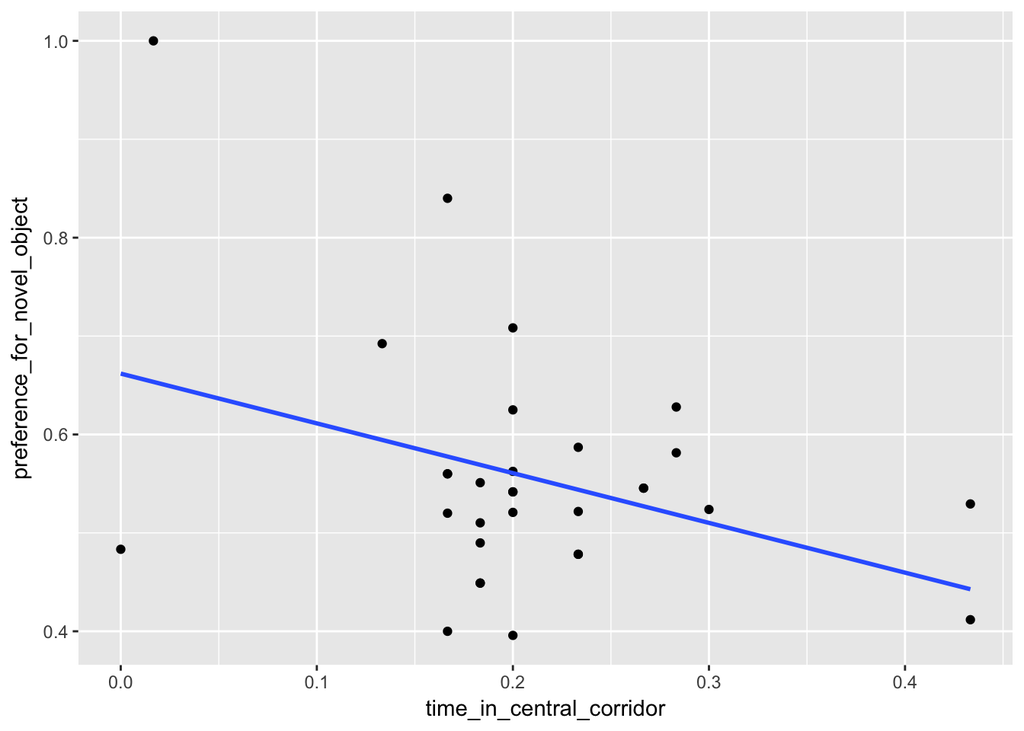

```r
ggplot(data = df, mapping = aes(time_in_central_corridor, preference_for_novel_object)) +
  geom_point() +
  geom_smooth(se = FALSE, method = "lm")
```

This is where we left off. I’ll modify it a couple ways to show how to change the plot:

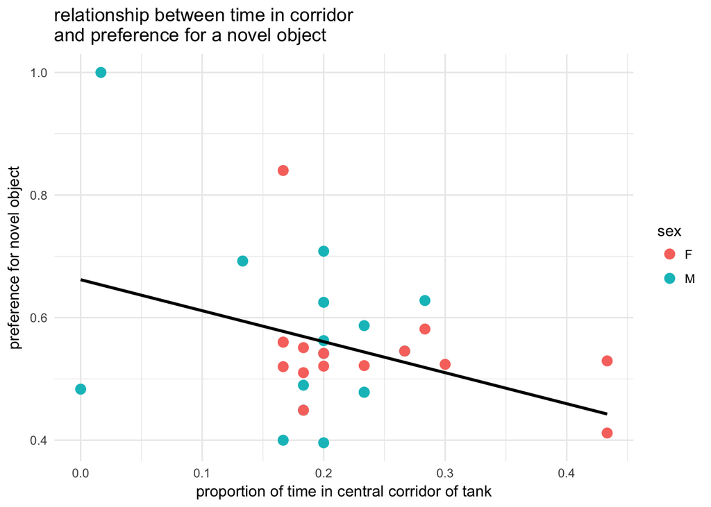

```r
ggplot(data = df, mapping = aes(time_in_central_corridor, preference_for_novel_object)) +
  geom_point(aes(color = sex), size = 3) +
  geom_smooth(se = FALSE, method = "lm", color = "black") +
  labs(title = "relationship between time in corridor\nand preference for a novel object",
       x = "proportion of time in central corridor of tank",
       y = "preference for novel object") +
  theme_minimal()
```

We can also ‘break up’ the plot into several smaller plots. Here, we might want a separate plot for males and females, which can be accomplished using the `facet_wrap` function:

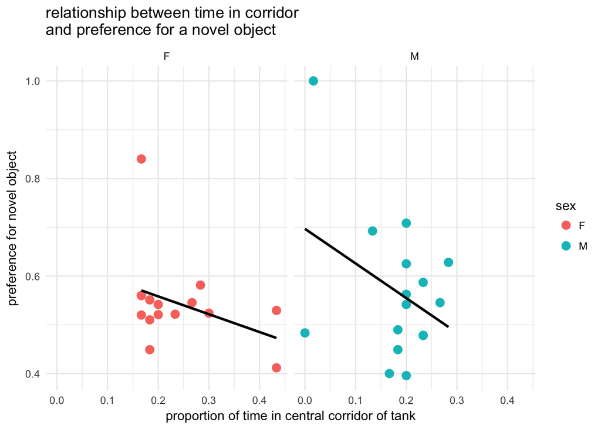

```r
ggplot(data = df, mapping = aes(time_in_central_corridor, preference_for_novel_object)) +
  geom_point(aes(color = sex), size = 3) +
  geom_smooth(se = FALSE, method = "lm", color = "black") +
  labs(title = "relationship between time in corridor\nand preference for a novel object",
       x = "proportion of time in central corridor of tank",
       y = "preference for novel object") +
  theme_minimal() +
  facet_wrap(~sex)
```

This plots highlights the benefits of this approach: we can now more clearly see that the negative relationship between the two variables is steeper in males than it is in females.

## additional resources

[This site](http://tryr.codeschool.com/) provides an easy way to learn the basics of R. [This book](http://r4ds.had.co.nz/) is extremely useful for learning how to best and most efficiently work with data in R. [These](https://www.rstudio.com/resources/cheatsheets/) cheatsheets from RStudio are also super useful.